# Structure and functionality

André Menezes

Last compiled on 2023-09-05

## Introduction

The `unitquantreg` R package provide efficient tools for estimation and inference in parametric quantile regression models for bounded data.

Available families of distributions their abbreviations and reference.

| Family | Abbreviation | Reference |
| --- | --- | --- |
| arc-secant hyperbolic Weibull | ashw | [Korkmaz et al. (2021)](https://www.tandfonline.com/doi/full/10.1080/02664763.2021.1981834) |
| Johnson-SB | johnsonsb | [Johnson (1949)](https://doi.org/10.2307/2332539) |
| Kumaraswamy | kum | [Kumaraswamy, (1980)](https://www.sciencedirect.com/science/article/abs/pii/0022169480900360) |
| log-extended Exponential-Geometric | leeg | [Jodrá and Jiménez-Gamero (2020)](https://doi.org/10.57805/revstat.v18i4.309) |
| unit-Birnbaum-Saunders | ubs | [Mazucheli, et al. (2021)](https://www.mdpi.com/2073-8994/13/4/682) |
| unit-Burr-XII | uburrxii | [Korkmaz and Chesneau (2021)](https://link.springer.com/article/10.1007/s40314-021-01418-5) |
| unit-Chen | uchen | [Korkmaz, et al. (2020)](https://doi.org/10.1515/ms-2022-0052) |
| unit-Generalized Half-Normal-E | ughne | [Korkmaz MÇ (2020)](https://www.scientificbulletin.upb.ro/rev_docs_arhiva/full6b9_464742.pdf) |
| unit-Generalized Half-Normal-X | ughnx | New |
| unit-Gompertz | ugompertz | [Mazucheli et al. (2019)](https://rivista-statistica.unibo.it/article/view/8497) |
| unit-Gumbel | ugumbel | New |
| unit-Logistic | ulogistic | [Tadikamalla and Johnson (1982)](https://doi.org/10.2307/2335422) |
| unit-Weibull | uweibull | Mazucheli, et al. (2018) |

The [`dpqr`]’s functions of the distributions are vectorized and implemented in `C++`. The log likelihood, score and hessian functions are also implemented in `C++` in order to guarantee more computational efficiency.

The parameter estimation and inference are performed under the frequentist paradigm. Maximization of the log-likelihood function is done by optimization techniques available in the `R` through the [`optimx`](https://CRAN.R-project.org/package=optimx) package, which is a general-purpose optimization wrapper function that allows the use of several `R` tools for optimization, including the existing `stats::optim()` function. To achieve quick and better convergence the analytical score function is use during the maximization. Also, standard errors of parameter estimates are computed using the analytical hessian matrix.

## Structure

The `unitquantreg` package is built around the `unitquantreg()` function which perform the fit of parametric quantile regression models via likelihood method. The `unitquantreg()` function has standard arguments as `stats::glm()` function, and they are as follows:

```
#> function (formula, data, subset, na.action, tau, family, link = c("logit",
#>     "probit", "cloglog", "cauchit"), link.theta = c("identity",
#>     "log", "sqrt"), start = NULL, control = unitquantreg.control(),
#>     model = TRUE, x = FALSE, y = TRUE)
#> NULL
```

The `formula` argument use the concept of [`Formula`](https://CRAN.R-project.org/package=Formula) package allows multiple parts on the right-hand side, which indicates regression structure for the quantile and shape parameter of the distribution. For instance, `formula = y ~ x1 | z1` means the following regression structure

$$g_1(\mu) = \beta_0 + \beta_1\,x_1 \quad \textrm{and} \quad g_2(\theta) =
\gamma_0 + \gamma_1\,z_1$$
where $\mu$ indicates the quantile of order $\tau$ and $\theta$ is the shape parameter.

The `tau` argument indicates the quantile(s) to be estimated, being possible to specify a vector of quantiles. `family` argument specify the distribution family using the abbreviation of `dpqr` functions, listed in Table above.

The `control` argument controls the fitting process through the `unitquantreg.control()` function which returned a `list` and the default values are:

```r
unlist(unitquantreg.control())
```

```
#>                 method                hessian               gradient
#>                 "BFGS"                "FALSE"                 "TRUE"
#>                  maxit                 reltol                  factr
#>                 "5000" "1.49011611938477e-08"                "1e+07"
#>                  trace                 dowarn             starttests
#>                    "0"                "FALSE"                "FALSE"
#>                fnscale
#>                    "1"
```

The two most important arguments are `hessian` and `gradient` which tell the `optimx::optimx()` whether it should use the numerical hessian matrix and the analytical score vector, respectively. That is, if `hessian = TRUE`, then the standard errors are computed using the numerical hessian matrix. For detailed description of other arguments see the package documentation.

### Object-oriented programming

The `unitquanreg()` function returns an object of class `unitquanreg` if the argument `tau` is scalar or `unitquanregs` if `tau` is a vector. The currently methods implemented for `unitquantreg` objects are:

```r
methods(class = "unitquantreg")
```

```
#>  [1] coef         confint      fitted       hnp          logLik
#>  [6] model.frame  model.matrix plot         predict      print
#> [11] residuals    summary      terms        update       vcov
#> see '?methods' for accessing help and source code
```

And for the `unitquantregs` objects are

```r
methods(class = "unitquantregs")
```

```
#> [1] plot    print   summary
#> see '?methods' for accessing help and source code
```

It is important to mention that the `unitquantregs` objects consists of a list with `unitquantreg` objects for according to the vector of `tau`.

Furthermore, the package provide functions designated for model comparison between `uniquantreg` objects. Particularly,

- `likelihood_stats()` function computes likelihood-based statistics (Neg2LogLike, AIC, BIC and HQIC),
- `vuong.test()` function performs Vuong test between two fitted **non nested** models,
- `pairwise.vuong.test()` function performs pairwise Vuong test with adjusted p-value according to `stats::p.adjust.methods` between fitted models

Finally, `uniquantreg` objects also permits use the inference methods functions `lmtest::coeftest()`, `lmtest::coefci`, `lmtest::coefci`, `lmtest::waldtest` and `lmtest::lrtest` implemented in [`lmtest`](https://CRAN.R-project.org/package=lmtest) to perform hypothesis test, confidence intervals for **nested models**.

Next, a detailed account of the usage of all these functions is provided.

## Functionality

As in [Mazucheli et al. (2020)](https://www.tandfonline.com/doi/abs/10.1080/02664763.2019.1657813?journalCode=cjas20) consider the data set related to the access of people in households with piped water supply in the cities of Brazil from the Southeast and Northeast regions. The response variable `phpws` is the proportion of households with piped water supply. The covariates are:

- `mhdi`: human development index.
- `incpc`: per capita income.
- `region`: 0 for southeast, 1 for northeast.
- `pop`: population.

```r
data(water)
head(water)
```

```
#>    phpws  mhdi  incpc region    pop
#> 1 0.8957 0.672 438.56      1 104047
#> 2 0.6777 0.529 149.78      1   5905
#> 3 0.8673 0.500 172.55      1  11581
#> 4 0.7363 0.573 209.27      1  21851
#> 5 0.7726 0.513 179.92      1  23952
#> 6 0.8824 0.549 164.24      1  11063
```

Assuming the following regression structure for the parameters:
$$\textrm{logit}(\mu_i) = \beta_0 + \beta_1 \texttt{mhdi}_{i1} + \beta_2
\texttt{incp}_{i2} +
\beta_3 \texttt{region}_{i3} + \beta_4
\log\left(\texttt{pop}_{i4}\right),$$
and
$$\log(\theta_i) = \gamma_0.$$
for $i = 1, \ldots, 3457$.

### Model fitting

For $\tau = 0.5$, that is, the median regression model we fitted for all families of distributions as follows:

```r
lt_families <- list("unit-Weibull" = "uweibull",
                    "Kumaraswamy" = "kum",
                    "unit-Logistic" = "ulogistic",
                    "unit-Birnbaum-Saunders" = "ubs",
                    "log-extended Exponential-Geometric" = "leeg",
                    "unit-Chen" = "uchen",
                    "unit-Generalized Half-Normal-E" = "ughne",
                    "unit-Generalized Half-Normal-X" = "ughnx",
                    "unit-Gompertz" = "ugompertz",
                    "Johnson-SB" = "johnsonsb",
                    "unit-Burr-XII" = "uburrxii",
                    "arc-secant hyperbolic Weibull" = "ashw",
                    "unit-Gumbel" = "ugumbel")
lt_fits <- lapply(lt_families, function(fam) {
  unitquantreg(formula = phpws ~ mhdi + incpc + region + log(pop),
               data = water, tau = 0.5, family = fam, link = "logit",
               link.theta = "log")
})
t(sapply(lt_fits, coef))
```

```
#>                                    (Intercept)      mhdi         incpc
#> unit-Weibull                         -6.514485 11.826177  2.600473e-04
#> Kumaraswamy                          -1.625951  4.843166  2.111029e-03
#> unit-Logistic                        -5.365469 10.508100  1.559636e-03
#> unit-Birnbaum-Saunders               -6.556648 13.723681  6.499360e-04
#> log-extended Exponential-Geometric   -4.712735  9.142144  1.928040e-03
#> unit-Chen                            -8.098012 13.560938 -6.162645e-05
#> unit-Generalized Half-Normal-E       -6.598061 11.731146 -1.037014e-04
#> unit-Generalized Half-Normal-X       -5.035562 13.186081  1.580614e-03
#> unit-Gompertz                        -6.260194 11.719934  4.103341e-04
#> Johnson-SB                           -5.993763 11.803290  1.144566e-03
#> unit-Burr-XII                        -5.811837 11.043123  3.777215e-04
#> arc-secant hyperbolic Weibull        -7.363838 12.705584  7.957473e-05
#> unit-Gumbel                          -9.338592 14.990026 -5.503130e-04
#>                                         region    log(pop)  log(theta)
#> unit-Weibull                       -0.26990871  0.10546762  0.17249694
#> Kumaraswamy                        -0.07860323 -0.04727081  1.75778137
#> unit-Logistic                      -0.15826000  0.01773368  0.63005907
#> unit-Birnbaum-Saunders             -0.18081222 -0.02300195  0.00832919
#> log-extended Exponential-Geometric -0.18882479  0.02252007  1.68797084
#> unit-Chen                          -0.48153890  0.19218762 -0.25568492
#> unit-Generalized Half-Normal-E     -0.37220694  0.14224250 -0.18418543
#> unit-Generalized Half-Normal-X     -0.16993805 -0.18341181 -0.38141377
#> unit-Gompertz                      -0.23932329  0.09146941 -5.42477111
#> Johnson-SB                         -0.19500756  0.01823070  0.01748328
#> unit-Burr-XII                      -0.19140000  0.07565710  0.28322367
#> arc-secant hyperbolic Weibull      -0.38168564  0.14972053  0.72098495
#> unit-Gumbel                        -0.62080389  0.25058612 -0.26073820
```

### Model comparison

Let’s check the likelihood-based statistics of fit

```r
likelihood_stats(lt = lt_fits)
```

```
#>
#>  Likelihood-based statistics of fit for unit quantile regression models
#>
#> Call:  likelihood_stats(lt = lt_fits)
#>
#>                                    Neg2LogLike AIC       BIC       HQIC
#> unit-Logistic                      -8443.029   -8431.029 -8394.140 -8417.855
#> Johnson-SB                         -8238.405   -8226.405 -8189.516 -8213.232
#> unit-Burr-XII                      -8096.114   -8084.114 -8047.225 -8070.941
#> unit-Weibull                       -7994.077   -7982.077 -7945.188 -7968.903
#> unit-Birnbaum-Saunders             -7955.990   -7943.990 -7907.101 -7930.817
#> unit-Gompertz                      -7808.838   -7796.838 -7759.949 -7783.664
#> arc-secant hyperbolic Weibull      -7679.482   -7667.482 -7630.593 -7654.308
#> log-extended Exponential-Geometric -7677.034   -7665.034 -7628.145 -7651.860
#> unit-Generalized Half-Normal-E     -7496.966   -7484.966 -7448.077 -7471.792
#> Kumaraswamy                        -7188.498   -7176.498 -7139.609 -7163.324
#> unit-Chen                          -7016.542   -7004.542 -6967.653 -6991.368
#> unit-Generalized Half-Normal-X     -6965.962   -6953.962 -6917.073 -6940.789
#> unit-Gumbel                        -6531.775   -6519.775 -6482.886 -6506.602
```

According to the statistics the unit-Logistic, Johnson-SB, unit-Burr-XII and unit-Weibull were the best models. Now, let’s perform the pairwise [vuong test](https://en.wikipedia.org/wiki/Vuong%27s_closeness_test) to check if there is statistical significant difference between the four models.

```r
lt_chosen <- lt_fits[c("unit-Logistic", "Johnson-SB", "unit-Burr-XII", "unit-Weibull")]
pairwise.vuong.test(lt = lt_chosen)
```

```
#>
#>  Pairwise comparisons using Vuong likelihood ratio test for non-nested models
#>
#> data:  unitquantreg(formula = phpws ~ mhdi + incpc + region + log(pop),
#>     data = water, tau = 0.5, family = fam, link = "logit", link.theta = "log")
#>
#>               unit-Logistic Johnson-SB unit-Burr-XII
#> Johnson-SB    0.00031       -          -
#> unit-Burr-XII 3.9e-07       0.09659    -
#> unit-Weibull  8.8e-11       0.00013    0.04868
#>
#> P value adjustment method: holm
```

### Diagnostic analysis

It is possible to check model assumptions from diagnostic plots using the `plot()` function method for `unitquantreg` objects. The `residuals()` method provides `quantile`, `cox-snell`, `working` and `partial` residuals type. The randomize quantile residuals is the default choice of `plot()` method.

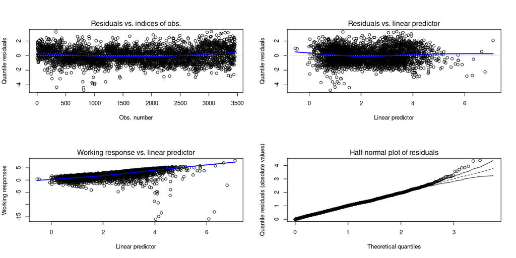

```r
oldpar <- par(no.readonly = TRUE)
par(mfrow = c(2, 2))
plot(lt_fits[["unit-Logistic"]])
```

```r
par(oldpar)
```

Plots of the residuals against the fitted linear predictor and the residuals against indices of observations are the tools for diagnostic analysis to check the structural form of the model. Two features of the plots are important:

- Trends: Any trends appearing in these plots indicate that the systematic component can be improved. This could mean changing the link function, adding extra explanatory variables, or transforming the explanatory variables.
- Constant variation: If the random component is correct then the variance of the points is approximately constant.

Working residuals versus linear predictor is used to check possible misspecification of link function and Half-normal plot of residuals to check distribution assumption.

Another best practice in diagnostic analysis is to inspect the (Half)-Normal plots with simulated envelope for several quantile value. This is done to obtain a more robust evaluation of the model assumptions. Thus, let’s fit the unit-Logistic quantile regression model for various quantiles.

```r
system.time(
  fits_ulogistic <- unitquantreg(formula = phpws ~ mhdi + incpc + region + log(pop),
                                 data = water, tau = 1:49/50,
                                 family = "ulogistic", link = "logit",
                                 link.theta = "log"))
```

```
#>    user  system elapsed
#>   7.957   0.000   7.957
```

Now, we can check the (Half)-Normal plots using the output of `hnp()` method.

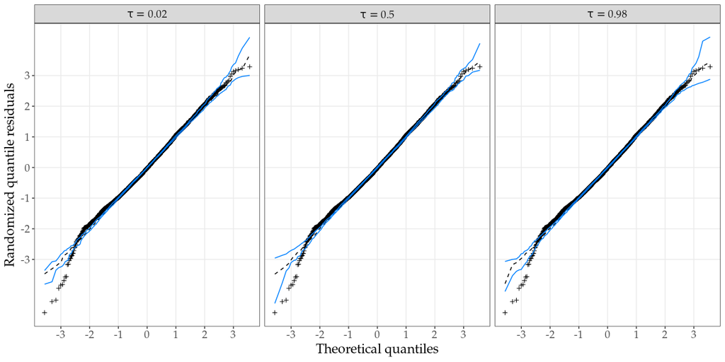

```r
library(ggplot2)
get_data <- function(obj) {
  tmp <- hnp(obj, halfnormal = FALSE, plot = FALSE, nsim = 10)
  tmp <- as.data.frame(do.call("cbind", tmp))
  tmp$tau <- as.character(obj$tau)
  tmp
}
chosen_taus <- c("0.02", "0.5", "0.98")
df_plot <- do.call("rbind", lapply(fits_ulogistic[chosen_taus], get_data))
df_plot$tau <- paste0(expression(tau), " == ", df_plot$tau)

ggplot(df_plot, aes(x = teo, y = obs)) +
  facet_wrap(~tau, labeller = label_parsed) +
  geom_point(shape = 3, size = 1.4) +
  geom_line(aes(y = median), linetype = "dashed") +
  geom_line(aes(y = lower), col = "#0080ff") +
  geom_line(aes(y = upper), col = "#0080ff") +
  theme_bw() +
  labs(x = "Theoretical quantiles", y = "Randomized quantile residuals") +
  scale_x_continuous(breaks = seq(-3, 3, by = 1)) +
  scale_y_continuous(breaks = seq(-3, 3, by = 1)) +
  theme_bw() +
  theme(text = element_text(size = 16, family = "Palatino"),
        panel.grid.minor = element_blank())
```

### Inference results

Inference results about the parameter estimates can be accessed through the `summary` method. For instance,

```r
summary(lt_fits[["unit-Logistic"]])
```

```
#>
#>  Wald-tests for unit-Logistic quantile regression model
#>
#> Call:  unitquantreg(formula = phpws ~ mhdi + incpc + region + log(pop),
#>     data = water, tau = 0.5, family = fam, link = "logit", link.theta = "log")
#>
#> Mu coefficients: (quantile model with logit link and tau = 0.5):
#>               Estimate Std. Error Z value Pr(>|z|)
#> (Intercept) -5.3654690  0.3373263 -15.906  < 2e-16 ***
#> mhdi        10.5080995  0.5717793  18.378  < 2e-16 ***
#> incpc        0.0015596  0.0001706   9.140  < 2e-16 ***
#> region      -0.1582600  0.0488825  -3.238  0.00121 **
#> log(pop)     0.0177337  0.0167306   1.060  0.28917
#> ---
#> Signif. codes:  0 '***' 0.001 '**' 0.01 '*' 0.05 '.' 0.1 ' ' 1
#>
#> Model with constant shape:
#>            Estimate Std. Error Z value Pr(>|z|)
#> log(theta)  0.63006    0.01421   44.35   <2e-16 ***
#> ---
#> Signif. codes:  0 '***' 0.001 '**' 0.01 '*' 0.05 '.' 0.1 ' ' 1
#>
#> Residual degrees of freedom: 3451
#> Log-likelihood: 4221.514
#> Number of iterations: 65
```

For `unitquantregs` objects the `plot` method provide a convenience to check the significance as well as the effect of estimate along the specify quantile value.

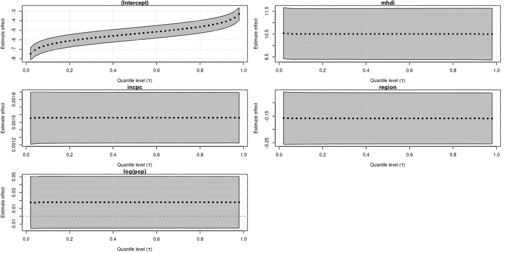

```r
plot(fits_ulogistic, which = "coef")
```

Curiously, the unit-Logistic quantile regression models capture constant effect for all covariates along the different quantiles. In contrast, the unit-Weibull model (the fourth best model) found a decrease effect of `mhdi` covaraite on the response as the quantile increases and increase effects of `incpc` and `region` on the response variable as the quantile increases.

```r
system.time(
  fits_uweibull <- unitquantreg(formula = phpws ~ mhdi + incpc + region + log(pop),
                                 data = water, tau = 1:49/50,
                                 family = "uweibull", link = "logit",
                                 link.theta = "log"))
```

```
#>    user  system elapsed
#>   8.719   0.000   8.720
```

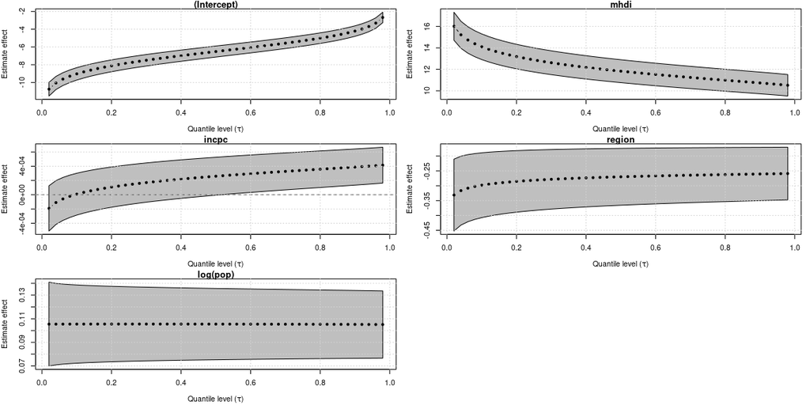

```r
plot(fits_uweibull, which = "coef")
```

Using the `plot()` method with argument `which = "conddist"` for `unitquantregs` objects it is possible to estimate and visualize the conditional distribution of a response variable at different values of covariates. For instance,

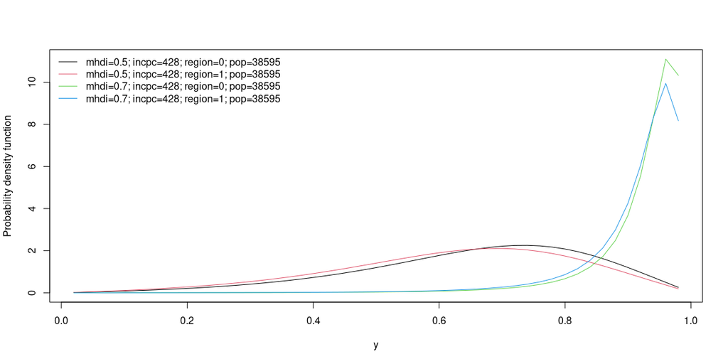

```r
lt_data <- list(mhdi = c(0.5, 0.7), incpc = round(mean(water$incpc)),
                region = c(1, 0), pop = round(mean(water$pop)))
plot(fits_ulogistic, which = "conddist", at_obs = lt_data, at_avg = FALSE,
     dist_type = "density")
```

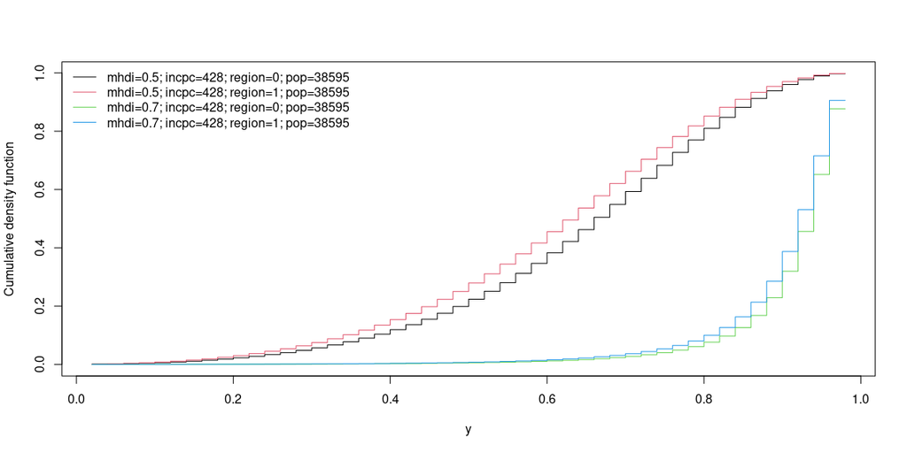

```r
plot(fits_ulogistic, which = "conddist", at_obs = lt_data, at_avg = FALSE,
     dist_type = "cdf")
```